# Obligatorio Taller de Aprendizaje Automatico

# OUTLIERS

Realizar un análisis de outliers en un modelo multivariado es algo complejo. Además, realizar un análisis univariado de outliers, puede no ser exacto o concluyente para este caso.

Se realizan varios ploteos en búsqueda de entender el comportamiento de las variables consideradas más significativas.

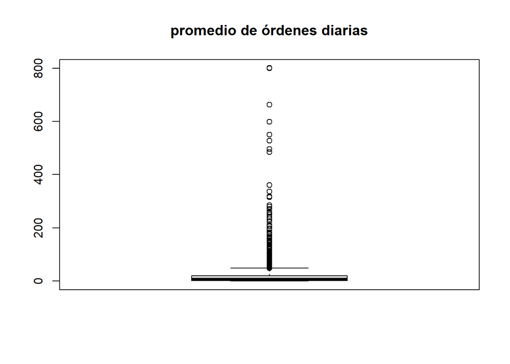

```r
boxplot(datos$order_dias, main="promedio de órdenes diarias")
```

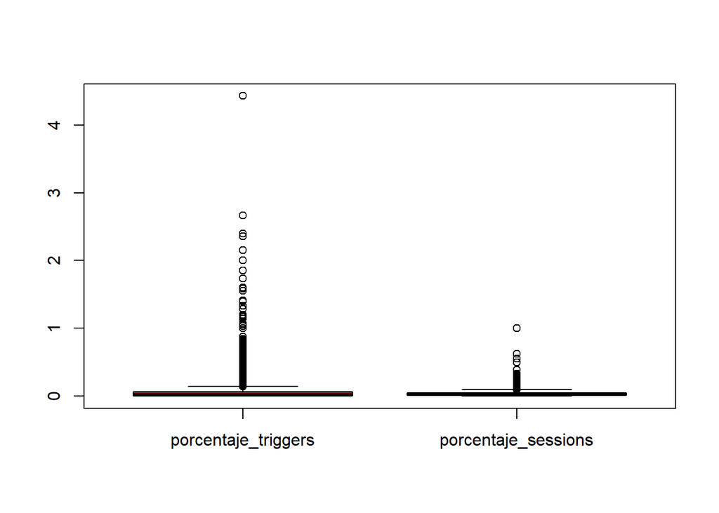

```r
var_porcentajes_1 <- select(datos,
                        porcentaje_triggers,
                        porcentaje_sessions,
                        )

var_porcentajes_2 <- select(datos,
                        porcentaje_ordenes_canceladas,
                        porcentaje_ordenes_confirmadas,
                        porcentaje_voucher,
                        )

var_porcentajes_3 <- select(datos,
                        porcentaje_sessions,
                        NPS,
                        porcentaje_fotos,
                        )

boxplot(var_porcentajes_1, col = rainbow(ncol(var_porcentajes_1)))
```

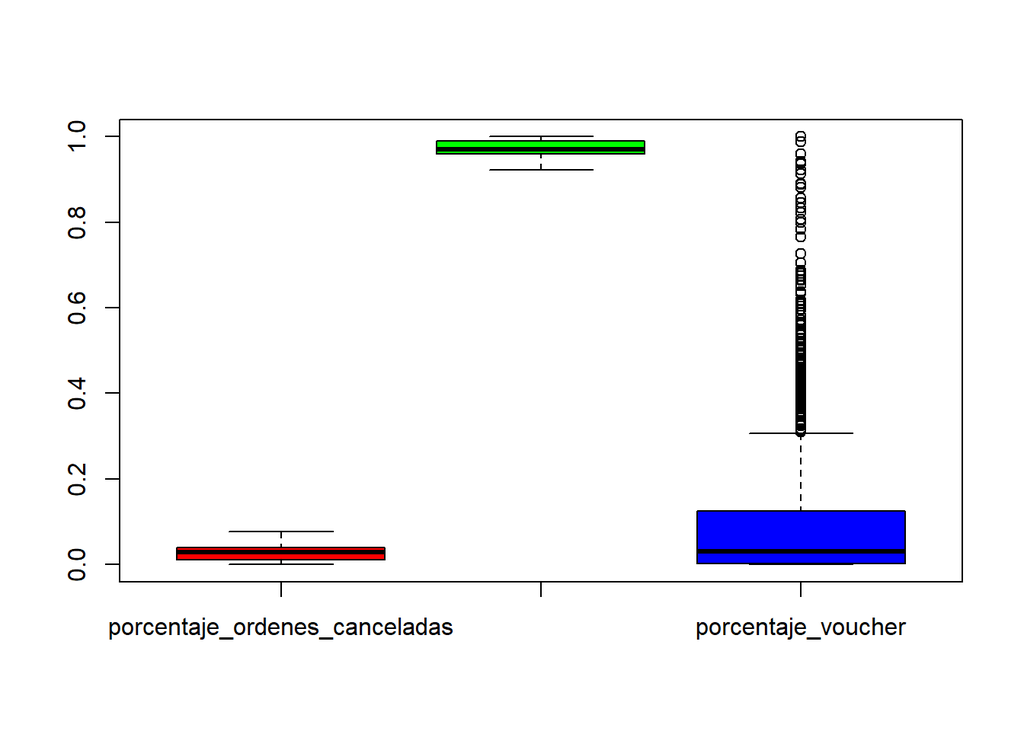

```r
boxplot(var_porcentajes_2, col = rainbow(ncol(var_porcentajes_2)))
```

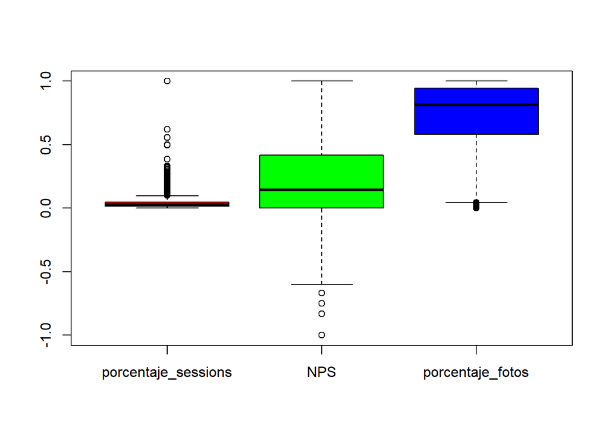

```r
boxplot(var_porcentajes_3, col = rainbow(ncol(var_porcentajes_3)))
```

Boxplot de la variable order_dias en conjunto con otras variables cualitativas

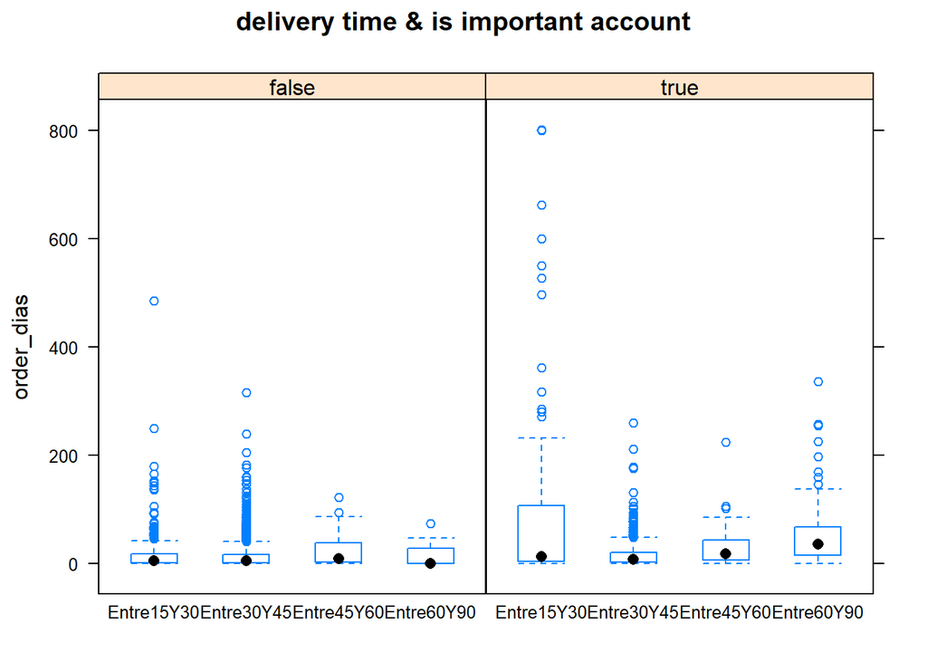

```r
bwplot(order_dias ~  delivery_time | is_important_account, data = datos, main="delivery time & is important account")
```

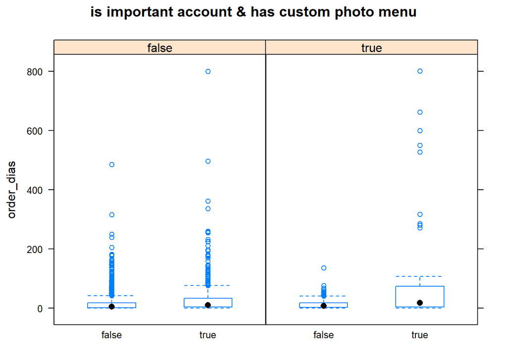

```r
bwplot(order_dias ~  is_important_account | has_custom_photo_menu, data = datos, main="is important account & has custom photo menu")
```

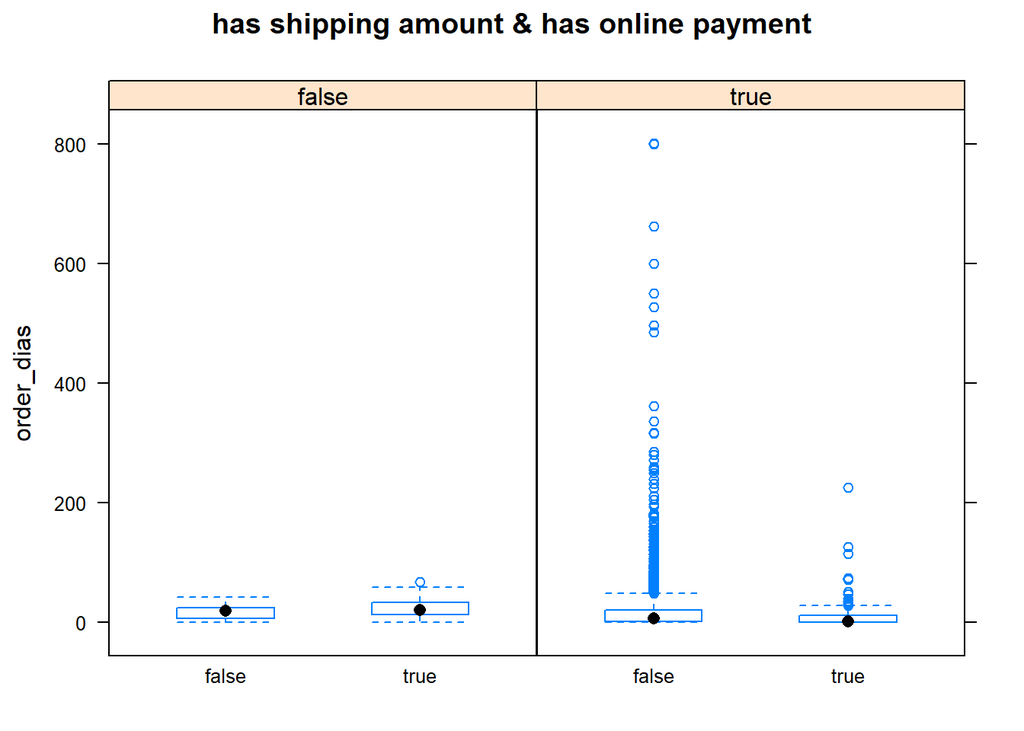

```r
bwplot(order_dias ~  has_shipping_amount | has_online_payment, data = datos, main="has shipping amount & has online payment")
```

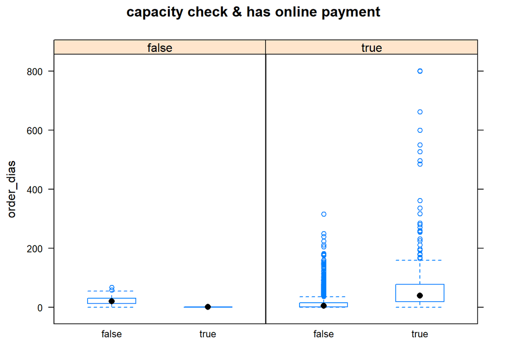

```r
bwplot(order_dias ~  capacity_check | has_online_payment, data = datos, main="capacity check & has online payment")
```

Luego de analizar estos gráficos, y tomando en cuenta que se está haciendo un análisis univariado y multivariado, se decide tomar acciones respecto a los outliers únicamente a la variable órdenes diarias.

```r
nrow(datos)
```

```
## [1] 3039
```

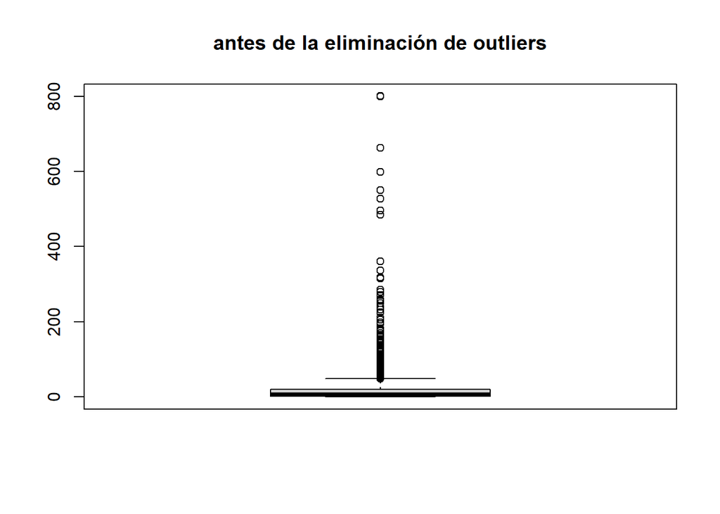

```r
boxplot(datos$order_dias, main="antes de la eliminación de outliers")
```

```r
datos_con_outliers = datos
# se eliminan los más lejanos de forma de mejorar la distribución
candidatos_outlier <- datos %>% filter(datos$order_dias>190)
datos <- datos[-which(datos$order_dias %in% candidatos_outlier$order_dias),]

nrow(candidatos_outlier)
```

```
## [1] 29
```

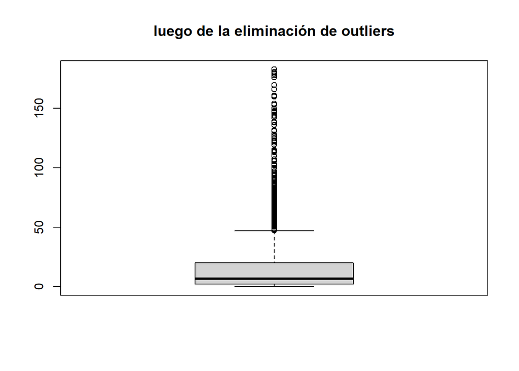

```r
boxplot(datos$order_dias, main="luego de la eliminación de outliers")
```

```r
nrow(datos)
```

```
## [1] 3010
```

# CORRELACION

```r
#Variables cuantitativas que se entienden mas relevantes (se quitan aquellas variables absolutas para las que se calcularon los ratios, así como también el porcentaje_orders_late por tenes NAs)
var_relevantes_cuanti <- select(
                        datos,
                        qty_products,
                        response_time_minute,
                        antiguedad,
                        order_dias,
                        chats_dias,
                        porcentaje_triggers,
                        porcentaje_voucher,
                        porcentaje_ordenes_canceladas,
                        porcentaje_ordenes_confirmadas,
                        porcentaje_sessions,
                        porcentaje_fotos,
                        NPS
                        )
summary(var_relevantes_cuanti)
```

```
##   qty_products     response_time_minute   antiguedad       order_dias
##  Min.   :   14.0   Min.   :  0.0024     Min.   :  4.00   Min.   :  0.00556
##  1st Qu.:  127.2   1st Qu.:  4.0770     1st Qu.:  6.00   1st Qu.:  1.92555
##  Median :  388.0   Median :  7.4207     Median :  9.00   Median :  6.68473
##  Mean   :  997.9   Mean   : 11.6573     Mean   : 10.46   Mean   : 16.33507
##  3rd Qu.:  832.8   3rd Qu.: 12.7345     3rd Qu.: 12.00   3rd Qu.: 19.98889
##  Max.   :22492.0   Max.   :505.0833     Max.   :120.00   Max.   :182.76667
##    chats_dias       porcentaje_triggers porcentaje_voucher
##  Min.   :0.000000   Min.   :0.000000    Min.   :0.000000
##  1st Qu.:0.000000   1st Qu.:0.007558    1st Qu.:0.002654
##  Median :0.006135   Median :0.020823    Median :0.031220
##  Mean   :0.130429   Mean   :0.077641    Mean   :0.099376
##  3rd Qu.:0.061111   3rd Qu.:0.062787    3rd Qu.:0.125102
##  Max.   :9.466667   Max.   :4.428571    Max.   :1.000000
##  porcentaje_ordenes_canceladas porcentaje_ordenes_confirmadas
##  Min.   :0.00000               Min.   :0.9231
##  1st Qu.:0.01079               1st Qu.:0.9601
##  Median :0.02954               Median :0.9705
##  Mean   :0.02560               Mean   :0.9744
##  3rd Qu.:0.03992               3rd Qu.:0.9892
##  Max.   :0.07692               Max.   :1.0000
##  porcentaje_sessions porcentaje_fotos      NPS
##  Min.   :0.00000     Min.   :0.0000   Min.   :-1.0000
##  1st Qu.:0.01565     1st Qu.:0.5747   1st Qu.: 0.0000
##  Median :0.02763     Median :0.8113   Median : 0.1429
##  Mean   :0.04063     Mean   :0.6919   Mean   : 0.2191
##  3rd Qu.:0.04901     3rd Qu.:0.9423   3rd Qu.: 0.4167
##  Max.   :1.00000     Max.   :1.0000   Max.   : 1.0000
```

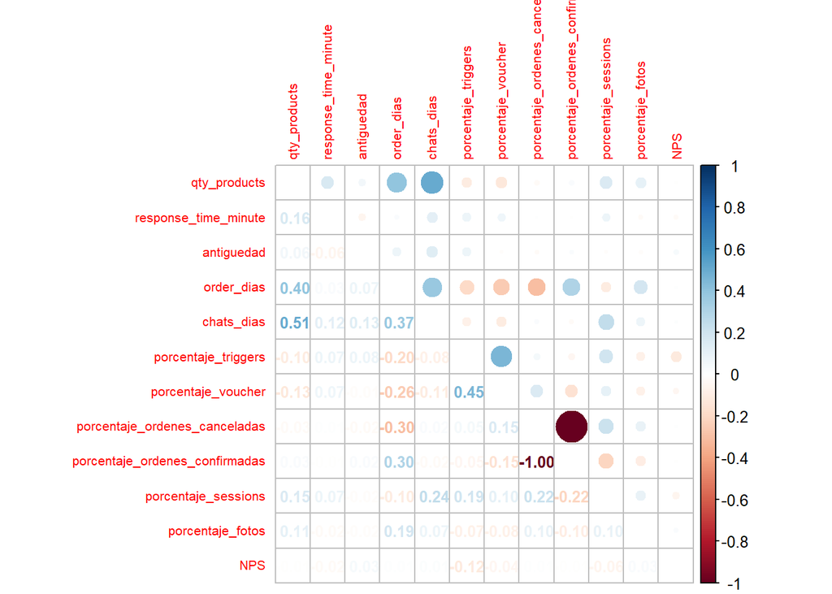

```r
# Matriz de correlacion para evaluar si las variables seleccionadas son adecuadas
# cor(var_relevantes_cuanti)
corrplot.mixed(cor(var_relevantes_cuanti), tl.pos="lt", number.cex=0.80, tl.cex=0.65)
```

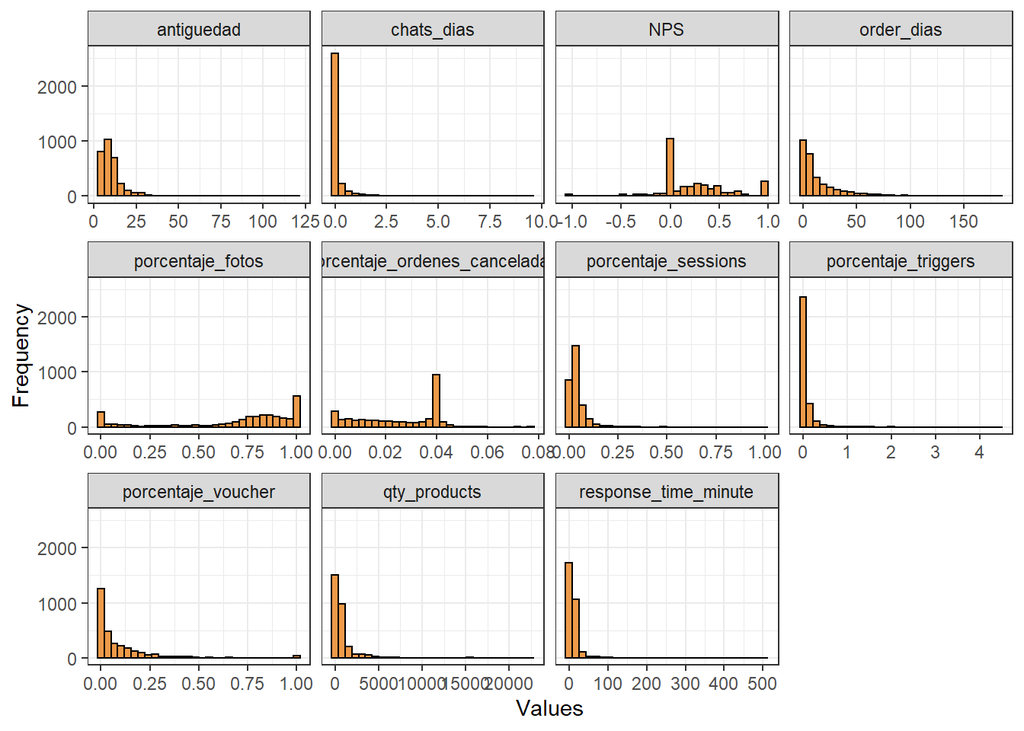

```r
# distribución de las variables

variables_cd = c("qty_products",
                    "response_time_minute",
                    "order_dias",
                    "antiguedad",
                    "chats_dias",
                    "porcentaje_triggers",
                    "porcentaje_voucher",
                    "porcentaje_ordenes_canceladas",
                    "porcentaje_sessions",
                    "porcentaje_fotos",
                    "NPS")


var_relevantes_cuanti %>%
  gather(attributes, value, variables_cd) %>%
  ggplot(aes(x = value)) +
  geom_histogram(fill = 'tan2', color = 'black') +
  facet_wrap(~attributes, scales = 'free_x') +
  labs(x="Values", y="Frequency") +
  theme_bw()
```

De acuerdo a la matriz de correlación, se elimina la variable porcentaje_ordenes_confirmadas debido a su alta correlación respecto a porcentaje_ordenes_canceladas, lo que era de esperarse.

```r
#variables para el modelo

datos_modelo <- select( datos,
                        partner_id,
                        qty_products,
                        response_time_minute,
                        antiguedad,
                        order_dias,
                        chats_dias,
                        porcentaje_triggers,
                        porcentaje_voucher,
                        porcentaje_ordenes_canceladas,
                        porcentaje_sessions,
                        porcentaje_fotos,
                        NPS,
                        has_online_payment,
                        capacity_check)


#head(datos_modelo,6)
```

# CLUSTERIZACION

## Escalado de variables

```r
# Selección de variables numericas

datos_modelo.numeric=datos_modelo
datos_modelo.numeric$partner_id=NULL
datos_modelo.numeric$has_online_payment=NULL
datos_modelo.numeric$capacity_check=NULL

datos_modelo.scale=scale(datos_modelo.numeric)
datos_modelo.scale=as.data.frame(datos_modelo.scale)
```

## Modelos C/Todas las variables

### Modelo PAM

Se crea un dataframe datos_modelo.colgow con las columnas para analisis de Gower, con las variables cualitativas y todas las columnas escaladas (datos_modelo.scale) Se obtiene la matriz de disimilitud usando la métrica de Gower

```r
datos_modelo.colgow=data.frame(has_online_payment=datos_modelo$has_online_payment, capacity_check=datos_modelo$capacity_check, datos_modelo.scale)

# matriz de disimilitud
modelo_distgower <- as.matrix(daisy(datos_modelo.colgow, metric = "gower"))
str(modelo_distgower)
```

```
##  num [1:3010, 1:3010] 0 0.198 0.195 0.176 0.175 ...
##  - attr(*, "dimnames")=List of 2
##   ..$ : chr [1:3010] "1" "2" "3" "4" ...
##   ..$ : chr [1:3010] "1" "2" "3" "4" ...
```

Método silueta para ver número de clusters.

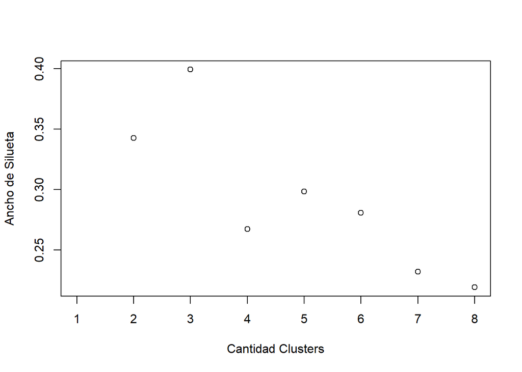

```r
set.seed(2222971)
sil_width <- c(NA)
for(i in 2:8){
  pam_fit <- pam(modelo_distgower, diss = TRUE, k = i)
  sil_width[i] <- pam_fit$silinfo$avg.width
}
plot(1:8, sil_width,
     xlab = "Cantidad Clusters",
     ylab = "Ancho de Silueta")
```

Si bien el gráfico indica que el número óptimo de clusters es 3

```r
modelo_pam_clusters <- pam(x = modelo_distgower, k = 3, diss=TRUE)
modelo_pam_clusters$clusinfo[,1]
```

```
## [1]  631 2153  226
```

Con 3 clusters, uno presenta mucho muchas observaciones respecto de los otros dos. Por tanto, se modela con 4 clusters.

```r
modelo_pam_clusters <- pam(x = modelo_distgower, k = 4, diss=TRUE)
modelo_pam_clusters$clusinfo[,1]
```

```
## [1]  593  983  226 1208
```

Visualización PAM

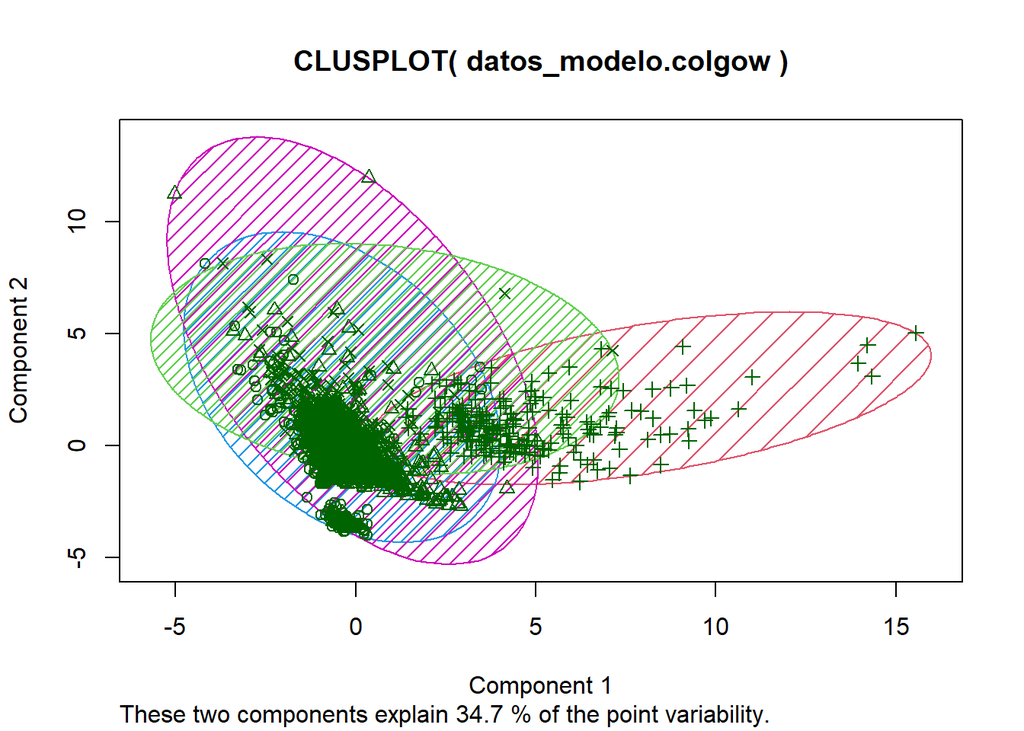

```r
model_data=datos_modelo.colgow
model_data$cluster_id <- modelo_pam_clusters$clustering

clusplot(datos_modelo.colgow,modelo_pam_clusters$clustering, color=TRUE, shade=TRUE)
```

### Modelo Kmeans

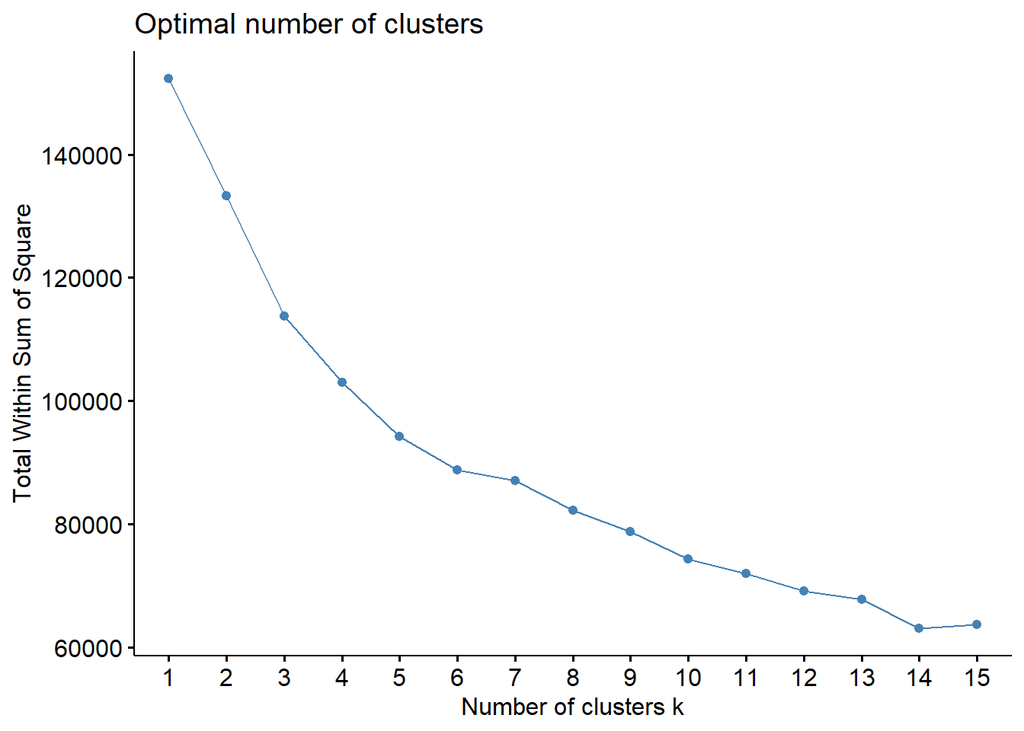

```r
# Método del codo para ver el número óptimo de clusters (distancia manhattan por ser más robusto a outliers)

fviz_nbclust(x = datos_modelo.scale, FUNcluster = kmeans, method = "wss", k.max = 15,
             diss = get_dist(datos_modelo.scale, method = "manhattan"), nstart = 10)
```

Se modela con 6 clusters

```r
set.seed(123)
km_clusters <- kmeans(x = datos_modelo.scale, centers = 6, nstart = 50)

km_clusters$size
```

```
## [1] 118 795 492 536 972  97
```

Visualización PCA k-means

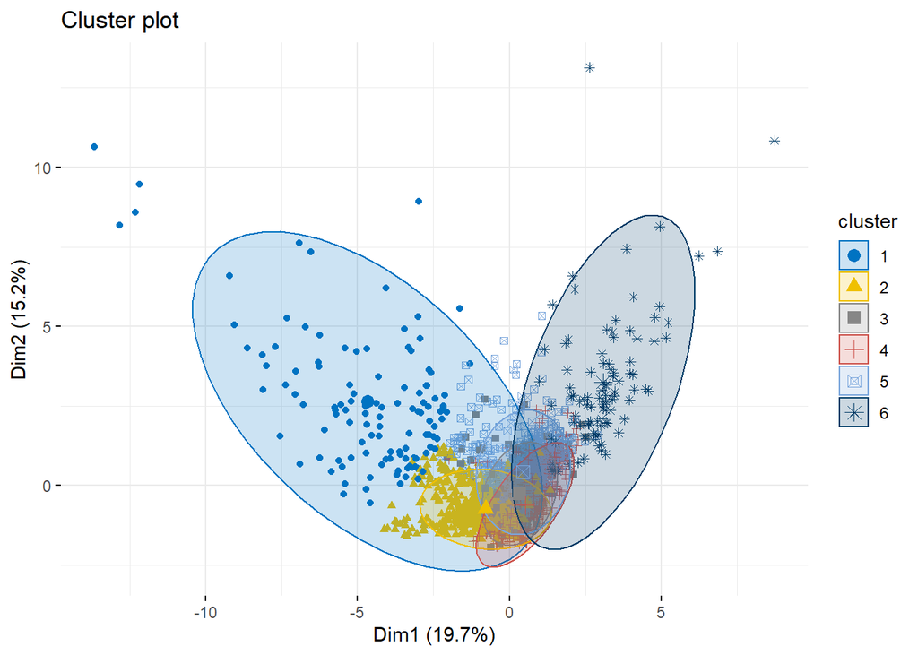

```r
km.resultado <- eclust(datos_modelo.scale, "kmeans", k = 6, nstart = 25, graph = FALSE)
fviz_cluster(km.resultado,geom = "point", ellipse.type = "norm", palette = "jco", ggtheme = theme_minimal())
```

Visualización de la segmentación en dos dimensiones

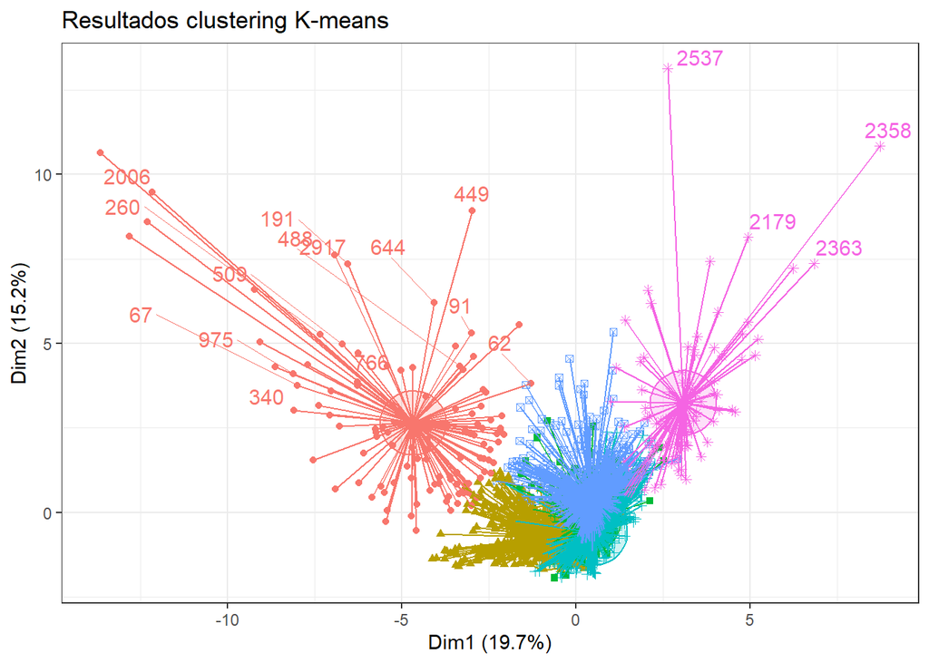

```r
fviz_cluster(object = km_clusters, data = datos_modelo.scale, show.clust.cent = TRUE,
             ellipse.type = "euclid", star.plot = TRUE, repel = TRUE) +
  labs(title = "Resultados clustering K-means") +
  theme_bw() +
  theme(legend.position = "none")
```

### Validación modelos

```r
km_clusters$size  #distribución observaciones en los clusters para Kmeans
```

```
## [1] 118 795 492 536 972  97
```

```r
modelo_pam_clusters$clusinfo[,1] #distribución observaciones en los clusters para PAM
```

```
## [1]  593  983  226 1208
```

```
##   cluster size ave.sil.width
## 1       1  593          0.20
## 2       2  983          0.23
## 3       3  226          0.45
## 4       4 1208          0.30
```

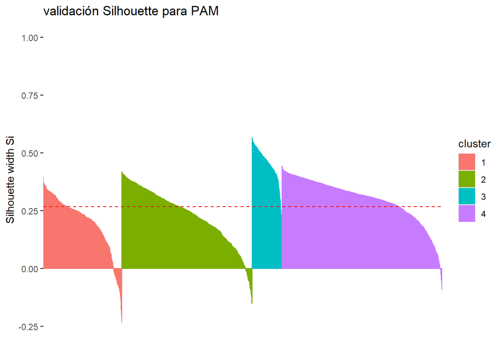

```r
cl <- modelo_pam_clusters
dis <- modelo_distgower
sil = silhouette (cl$cluster, dis)
fviz_silhouette(sil, main="validación Silhouette para PAM")
```

```
##   cluster size ave.sil.width
## 1       1  118         -0.02
## 2       2  795          0.19
## 3       3  492          0.19
## 4       4  536          0.15
## 5       5  972          0.19
## 6       6   97          0.00
```

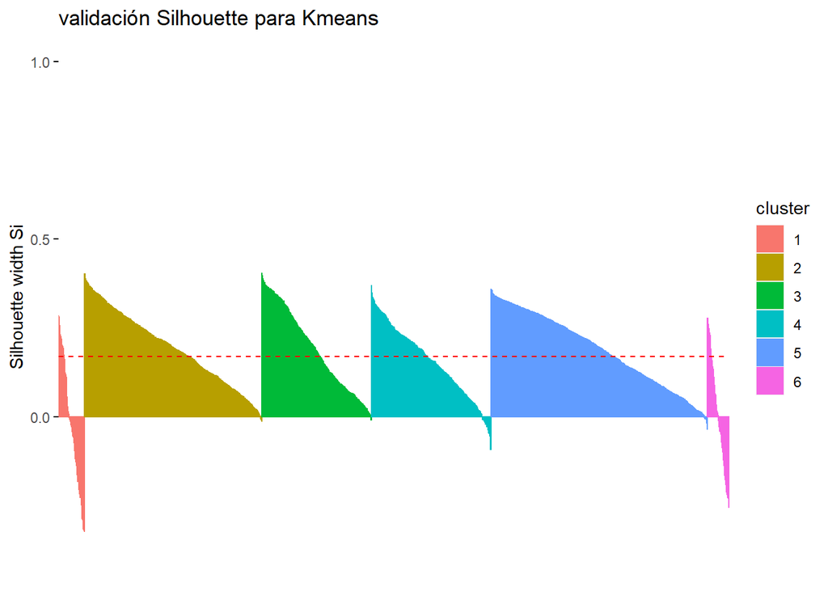

```r
cl_k <- km_clusters
dis_k <- dist(datos_modelo.scale)
sil_k = silhouette (cl_k$cluster, dis_k)
fviz_silhouette(sil_k, main="validación Silhouette para Kmeans")
```

## Modelos C/Menos variables

Ahora se verá si reduciendo la cantidad de variables en los modelos, se obtienen iguales o mejores resultados diferentes en la clusterización.

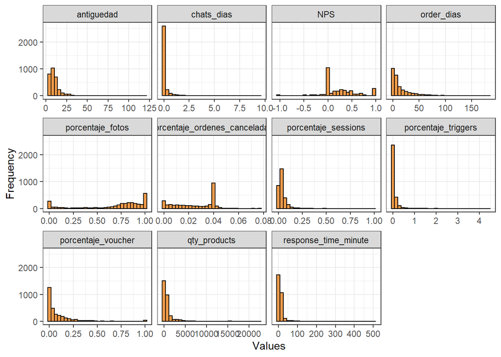

```r
# histograma con distribución de las variables cuantitativas

variables_c = c("qty_products",
                    "response_time_minute",
                    "order_dias",
                    "antiguedad",
                    "chats_dias",
                    "porcentaje_triggers",
                    "porcentaje_voucher",
                    "porcentaje_ordenes_canceladas",
                    "porcentaje_sessions",
                    "porcentaje_fotos",
                    "NPS")

datos %>%
  gather(attributes, value, variables_c) %>%
  ggplot(aes(x = value)) +
  geom_histogram(fill = 'tan2', color = 'black') +
  facet_wrap(~attributes, scales = 'free_x') +
  labs(x="Values", y="Frequency") +
  theme_bw()
```

Viendo aquellas variables cuya distribución es mas “chata” y por tanto no aportan mucha información, se tomará un espacio de variables menor descartando porcentaje_fotos. Por otro lado, las variables que presentan un histograma no suficientemente distribuido como chats_dias también se eliminan. Luego de varias corridas de los modelos, se comprueba que quitando también las variables antiguedad, qty_products y NPS, se obtuvieron los mejores resultados en la clusterización, con un menor número de variables.

```r
datos_modelo_sel <- select(datos,
                    partner_id,
                    response_time_minute,
                    order_dias,
                    porcentaje_triggers,
                    porcentaje_voucher,
                    porcentaje_sessions,
                    porcentaje_ordenes_canceladas,
                    has_online_payment,
                    capacity_check)
```

```r
# Selección de variables numericas

datos_sel_numeric=datos_modelo_sel
datos_sel_numeric$partner_id=NULL
datos_sel_numeric$has_online_payment=NULL
datos_sel_numeric$capacity_check=NULL

datos_sel.scale=scale(datos_sel_numeric)
datos_sel.scale=as.data.frame(datos_sel.scale)
```

### Modelo PAM

Matriz de disimilitud usando la métrica de Gower

```r
datos_sel.colgow=data.frame(has_online_payment=datos_modelo_sel$has_online_payment, capacity_check=datos_modelo_sel$capacity_check, datos_sel.scale)

modelo_distgower_sel <- as.matrix(daisy(datos_sel.colgow, metric = "gower"))
str(modelo_distgower_sel)
```

```
##  num [1:3010, 1:3010] 0 0.208 0.172 0.15 0.162 ...
##  - attr(*, "dimnames")=List of 2
##   ..$ : chr [1:3010] "1" "2" "3" "4" ...
##   ..$ : chr [1:3010] "1" "2" "3" "4" ...
```

Metodo silueta para ver número de clusters

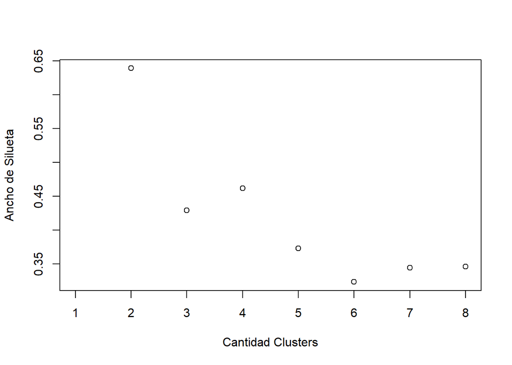

```r
set.seed(2222971)
sil_width <- c(NA)
for(i in 2:8){
  pam_fit <- pam(modelo_distgower_sel, diss = TRUE, k = i)
  sil_width[i] <- pam_fit$silinfo$avg.width
}
plot(1:8, sil_width,
     xlab = "Cantidad Clusters",
     ylab = "Ancho de Silueta")
```

Modelo PAM con 4 clusters

```r
sel_pam_clusters <- pam(x = modelo_distgower_sel, k = 4, diss=TRUE)
sel_pam_clusters$clusinfo[,1]
```

```
## [1]  104 1516 1163  227
```

### Modelo Kmeans

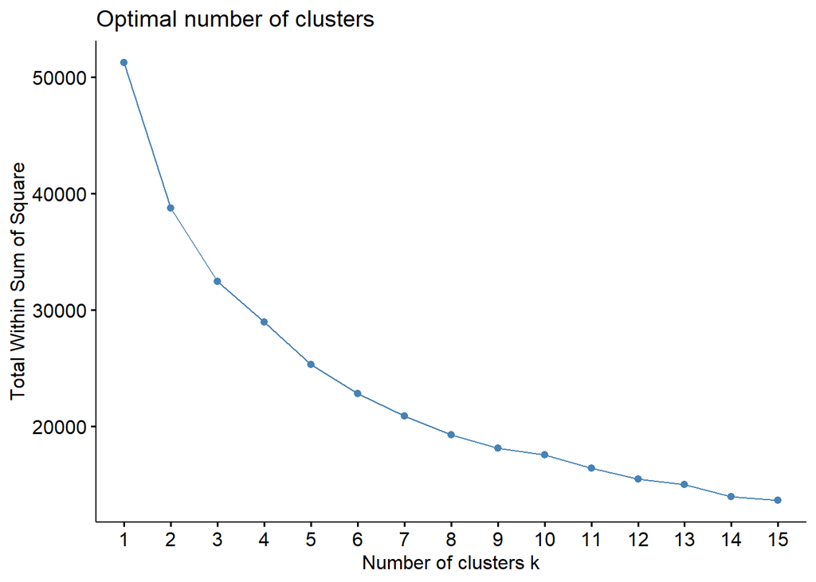

```r
# Método del codo para ver el número óptimo de clusters (distancia manhattan por ser más robusto a outliers)

fviz_nbclust(x = datos_sel.scale, FUNcluster = kmeans, method = "wss", k.max = 15,
             diss = get_dist(datos_sel.scale, method = "manhattan"), nstart = 10)
```

```r
set.seed(123)
sel_km_clusters <- kmeans(x = datos_sel.scale, centers = 5, nstart = 50)

sel_km_clusters$size
```

```
## [1]   95 1093   29 1543  250
```

Al quedar un clusters solamente con 29 observaciones, se toma k=4

```r
set.seed(123)
sel_km_clusters <- kmeans(x = datos_sel.scale, centers = 4, nstart = 50)

sel_km_clusters$size
```

```
## [1]   65   95 1262 1588
```

### Validación modelos

```r
sel_km_clusters$size  #distrbución observaciones en los clusters para Kmeans
```

```
## [1]   65   95 1262 1588
```

```r
sel_pam_clusters$clusinfo[,1] #distrbución observaciones en los clusters para PAM
```

```
## [1]  104 1516 1163  227
```

```
##   cluster size ave.sil.width
## 1       1  104          0.80
## 2       2 1516          0.49
## 3       3 1163          0.37
## 4       4  227          0.62
```

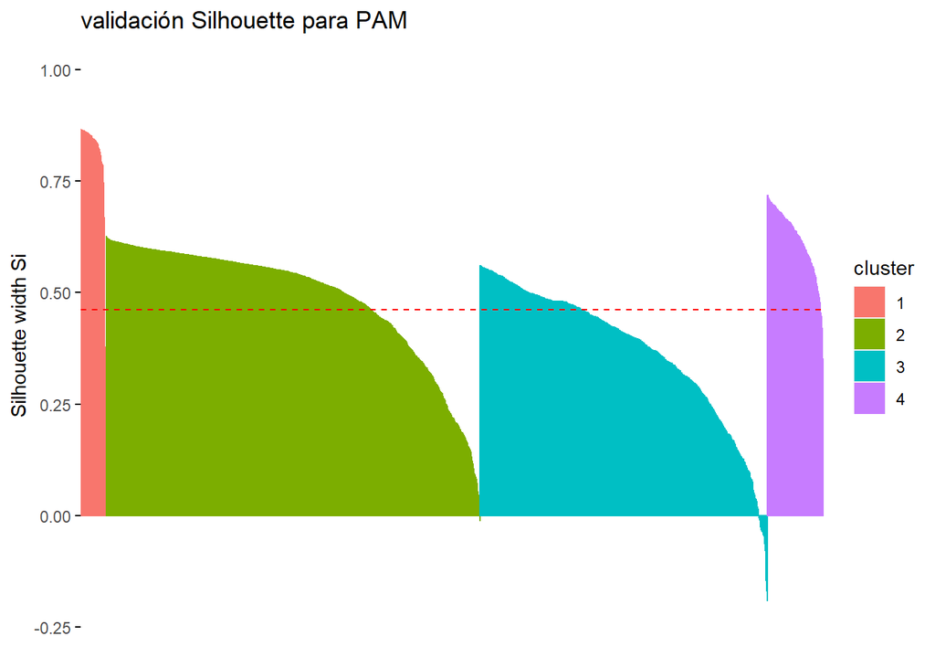

```r
cl <- sel_pam_clusters
dis <- modelo_distgower_sel
sil = silhouette (cl$cluster, dis)
fviz_silhouette(sil, main="validación Silhouette para PAM")
```

```
##   cluster size ave.sil.width
## 1       1   65          0.08
## 2       2   95          0.09
## 3       3 1262          0.30
## 4       4 1588          0.36
```

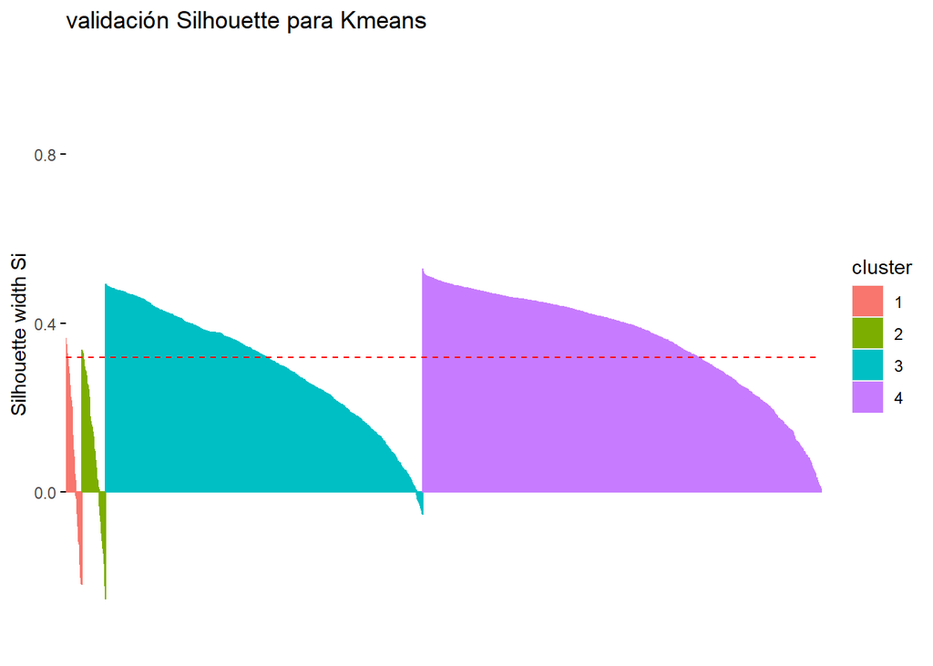

```r
cl_k <- sel_km_clusters
dis_k <- dist(datos_sel.scale)
sil_k = silhouette (cl_k$cluster, dis_k)
fviz_silhouette(sil_k, main="validación Silhouette para Kmeans")
```

## Modelo seleccionado

Se concluye que con la eliminación de algunas variables no solo se obtiene un modelo más sencillo, y seguramente según el principio de parsimonia sea una mejor representación de la realidad, sino que además se obtiene un mejor resultado en la clusterización. Evaluando los modelos PAM y K-means para este set de variables, se observa que el resultado de PAM es muy superior al del 2do. Para el modelo final se elije PAM con el dataset reducido de variables.

```r
modelo_final = sel_pam_clusters
```

## Partners Clusterizados

Registros clusterizados

```r
# Obtención de un vector con la clusterizacion
modelo_clus=as.vector(modelo_final$clustering)

# vínculo del dataframe con partnerid, al vector con cluster
modelo_clusterizado=datos_modelo_sel
modelo_clusterizado$nrocluster=modelo_clus #datos modelo con nro cluster
```

Se asigna el nro de cluster al dataframe completo (filtrado, pero con todas las variables y los outliers incluidos) utlizando la funcionalidad merge por partnerId. Solamente se completan los valores para los registros que se hayan clusterizado, en caso de haber eliminado outliers estos quedaran con valor N/A en la columna correspondiente a su cluster y deberán ser asignados en la etapa de asignación.

```r
datos_full_modelo = datos_con_outliers #todas las variables + outliers
modelo_clusters = data.frame(partner_id=modelo_clusterizado$partner_id, nrocluster=modelo_clusterizado$nrocluster) #data frame solamente con partner_id y nrocluster

# todas las variables + outliers + nrcluster
datos_full_modelo=merge(x=datos_full_modelo, y=modelo_clusters, by="partner_id",all.x=TRUE)

summary(datos_full_modelo$nrocluster)
```

```
##    Min. 1st Qu.  Median    Mean 3rd Qu.    Max.    NA's
##   1.000   2.000   2.000   2.503   3.000   4.000      29
```

# ASIGNACION

En este caso se trabajará sobre los registros que no participaron del algoritmo de clusterizacion, y se asignará manualmente a algunos de los clusters. Para ello, luego de escalarlos, se calcula la disimilitud de cada uno con relacion a los medoides identificados para cada cluster y cada variable, y se asigna de modo que se minimice la disimilitud.

Se filtran las filas que quedaron sin clusterizar del total de registros

```r
# Datos_full_modelo que no tienen cluster asignado
incluster=filter(datos_full_modelo, is.na(nrocluster))

# Se obtienen los medoides de cada cluster desde el dataframe del modelo, con las columnas especificas
medoides=datos_modelo_sel[modelo_final$id.med,] #matriz con medoides para cada variable del modelo ordenado por nro de cluster
# para verificar que está ordenado por nro de cluster:
modelo_clusterizado[modelo_final$id.med,]$nrocluster
```

```
## [1] 1 2 3 4
```

```r
#dataframe con los outliers de acuerdo a las variables usadas en el modelado PAM
outliers=data.frame(partner_id=incluster$partner_id,incluster[colnames(datos_sel.colgow)])
```

```r
# Se obtiene el escalado del cluster y se utiliza para escalar los outliers. Para intentar mantener la relatividad, se podría haber utilizado el scale, pero tratándose de outliers podrían dar distintas medidas.
clus=datos_modelo_sel
clusnum=as.data.frame(dplyr::select_if(clus, is.numeric)) #solo las variables numéricas
clusmedia=apply(clusnum, 2, mean, na.rm = TRUE) # media del dataset de modelado
clusSd=apply(clusnum, 2, sd, na.rm = TRUE) # SD del dataset de modelado

outliers.scale=(outliers-clusmedia)/clusSd
outliers.scale$has_online_payment=outliers$has_online_payment
outliers.scale$capacity_check=outliers$capacity_check

aux=rbind(outliers.scale, medoides)  # a los oultiers escalados, se agregan las con los medoides

aux1=aux
aux1$partner_id=NULL
```

Se crea la matriz de distancia entre observaciones y medoides utilizando gower

```r
distout <- as.matrix(daisy(aux1, metric = "gower"))
distout<-as.data.frame(distout)
```

Matriz de distancia entre los medoides y las observaciones de los outliers

```r
distout=distout[1:(nrow(distout) - nrow(medoides)),]
distout=distout[,(ncol(distout)-nrow(medoides)+1):(ncol(distout))] #distancia entre outliers y medoides
```

Se busca a cual medoide pertenece cada observacion, eligiendo aquel que minimiza la disimilitud entre la observacion y cada uno de los medoides.

```r
clu <- c(NA)
for(i in (1:nrow(distout))){
  clu[i]=which.min(distout[i,])
}
# se asigna el cluster i donde la distancia se minimiza en la posición de columna i (columna i = cluster i)
distout$clu=clu

outliers$nrocluster=clu
```

Se agrega al dataset una columna cluster resultante de esta logica en columna separada cluster2, y luego se copia este valor en la columna de clusterizacion original, para los casos donde no hay datos en la misma.

```r
aux2=data.frame(partner_id=outliers$partner_id, nrocluster2=outliers$nrocluster)
datos_full_modelo=merge(x=datos_full_modelo, y=aux2, by="partner_id", all.x=TRUE)
datos_full_modelo$nrocluster=ifelse(!is.na(datos_full_modelo$nrocluster), datos_full_modelo$nrocluster, datos_full_modelo$nrocluster2)
datos_full_modelo$nrocluster2=NULL
```

# CARACTERIZACION

```r
datos_primarios_cuanti <- select(datos_full_modelo,
                                 qty_products,
                                 qty_picts,
                                 qty_triggers,
                                 qty_order_late_10,
                                 response_time_minute,
                                 voucher_orders,
                                 rejected_orders,
                                 chats,
                                 sessions,
                                 antiguedad,
                                 order_dias,
                                 porcentaje_triggers,
                                 porcentaje_voucher,
                                 porcentaje_ordenes_canceladas,
                                 chats_dias,
                                 porcentaje_sessions,
                                 NPS,
                                 porcentaje_fotos,
                                 porcentaje_orders_late,
                                 nrocluster)


datos_primarios_cuali = select(datos_full_modelo,
                               business_type_name,
                               delivery_time,
                               has_shipping_amount,
                               has_discount,
                               has_online_payment,
                               is_important_account,
                               accepts_vouchers,
                               accepts_pre_order,
                               has_mov,
                               has_custom_photo_menu,
                               capacity_check,
                               is_logistic)
```

## Caracterización cualitativa

```r
print("por tipo de negocio")
```

```
## [1] "por tipo de negocio"
```

```r
table(datos_full_modelo$nrocluster,datos_primarios_cuali$business_type_name)
```

```
##
##     Coffee Drinks Kiosks Market Pharmacy Restaurant Shop
##   1      0      0      2    102        0          0    0
##   2      0      0    736    780        0          0    0
##   3      0      0    574    595        0          0    0
##   4      0      0      0    250        0          0    0
```

```r
print("por tiempo de envío")
```

```
## [1] "por tiempo de envío"
```

```r
table(datos_full_modelo$nrocluster,datos_primarios_cuali$delivery_time)
```

```
##
##     Entre120Y150 Entre150Y180 Entre15Y30 Entre30Y45 Entre45Y60 Entre60Y90
##   1            0            0          5         99          0          0
##   2            0            0        228       1209         78          1
##   3            0            0        184        936         47          2
##   4            0            0         44         60         18        128
##
##     Entre90Y120 Horas12 Horas48
##   1           0       0       0
##   2           0       0       0
##   3           0       0       0
##   4           0       0       0
```

```r
print("si tiene costo de envío")
```

```
## [1] "si tiene costo de envío"
```

```r
table(datos_full_modelo$nrocluster,datos_primarios_cuali$has_shipping_amount)
```

```
##
##     false true
##   1    17   87
##   2  1401  115
##   3  1081   88
##   4   225   25
```

```r
print("si tiene pago online")
```

```
## [1] "si tiene pago online"
```

```r
table(datos_full_modelo$nrocluster,datos_primarios_cuali$has_online_payment)
```

```
##
##     false true
##   1   104    0
##   2     0 1516
##   3     0 1169
##   4     2  248
```

```r
print("si tiene descuento")
```

```
## [1] "si tiene descuento"
```

```r
table(datos_full_modelo$nrocluster,datos_primarios_cuali$has_discount)
```

```
##
##     false true
##   1   104    0
##   2  1515    1
##   3  1168    1
##   4   249    1
```

```r
print("si es una cuenta importante")
```

```
## [1] "si es una cuenta importante"
```

```r
table(datos_full_modelo$nrocluster,datos_primarios_cuali$is_important_account)
```

```
##
##     false true
##   1   103    1
##   2  1258  258
##   3   921  248
##   4    14  236
```

```r
print("si tiene valor mínimo de compra")
```

```
## [1] "si tiene valor mínimo de compra"
```

```r
table(datos_full_modelo$nrocluster,datos_primarios_cuali$has_mov)
```

```
##
##     false true
##   1    99    5
##   2   171 1345
##   3   143 1026
##   4     8  242
```

```r
print("si acepta vouchers")
```

```
## [1] "si acepta vouchers"
```

```r
table(datos_full_modelo$nrocluster,datos_primarios_cuali$accepts_vouchers)
```

```
##
##     false true
##   1     0  104
##   2    96 1420
##   3   104 1065
##   4    11  239
```

```r
print("si acepta pre órdenes")
```

```
## [1] "si acepta pre órdenes"
```

```r
table(datos_full_modelo$nrocluster,datos_primarios_cuali$accepts_pre_order)
```

```
##
##     false true
##   1     0  104
##   2   142 1374
##   3   162 1007
##   4     0  250
```

```r
print("si tiene fotos de clientes")
```

```
## [1] "si tiene fotos de clientes"
```

```r
table(datos_full_modelo$nrocluster,datos_primarios_cuali$has_custom_photo_menu)
```

```
##
##     false true
##   1    74   30
##   2  1346  170
##   3  1043  126
##   4   240   10
```

```r
print("si tiene límites de órdenes")
```

```
## [1] "si tiene límites de órdenes"
```

```r
table(datos_full_modelo$nrocluster,datos_primarios_cuali$capacity_check)
```

```
##
##     false true
##   1   104    0
##   2  1516    0
##   3  1169    0
##   4     0  250
```

```r
print("si tiene delivery por PeYa")
```

```
## [1] "si tiene delivery por PeYa"
```

```r
table(datos_full_modelo$nrocluster,datos_primarios_cuali$is_logistic)
```

```
##
##     false true
##   1     0  104
##   2    67 1449
##   3    37 1132
##   4     1  249
```

## Caracterización cuantitativa

```r
Promedio = apply(datos_primarios_cuanti,2,mean)
Promedio
```

```
##                  qty_products                     qty_picts
##                  1.060506e+03                  8.275627e+02
##                  qty_triggers             qty_order_late_10
##                  4.377131e+01                            NA
##          response_time_minute                voucher_orders
##                  1.169935e+01                  8.922507e+01
##               rejected_orders                         chats
##                  5.793452e+01                  3.315169e+01
##                      sessions                    antiguedad
##                  1.153034e+02                  1.048075e+01
##                    order_dias           porcentaje_triggers
##                  1.957260e+01                  7.693265e-02
##            porcentaje_voucher porcentaje_ordenes_canceladas
##                  9.843870e-02                  2.546550e-02
##                    chats_dias           porcentaje_sessions
##                  1.886989e-01                  4.060994e-02
##                           NPS              porcentaje_fotos
##                  2.193933e-01                  6.937381e-01
##        porcentaje_orders_late                    nrocluster
##                            NA                  2.514972e+00
```

```r
variables=names(Promedio)
variables
```

```
##  [1] "qty_products"                  "qty_picts"
##  [3] "qty_triggers"                  "qty_order_late_10"
##  [5] "response_time_minute"          "voucher_orders"
##  [7] "rejected_orders"               "chats"
##  [9] "sessions"                      "antiguedad"
## [11] "order_dias"                    "porcentaje_triggers"
## [13] "porcentaje_voucher"            "porcentaje_ordenes_canceladas"
## [15] "chats_dias"                    "porcentaje_sessions"
## [17] "NPS"                           "porcentaje_fotos"
## [19] "porcentaje_orders_late"        "nrocluster"
```

```r
# se calculan los promedios de cada cluster de cada una de las variables
cluster1 = apply(subset(datos_primarios_cuanti,datos_primarios_cuanti$nrocluster==1),2, mean)

cluster2 = apply(subset(datos_primarios_cuanti,datos_primarios_cuanti$nrocluster==2),2, mean)

cluster3 = apply(subset(datos_primarios_cuanti,datos_primarios_cuanti$nrocluster==3),2, mean)

cluster4 = apply(subset(datos_primarios_cuanti,datos_primarios_cuanti$nrocluster==4),2, mean)
```

```r
#se construye un dataset que contiene los promedios de cada variable por cluster y el promedio de todo el universo.
Final=data.frame(variables, cluster1,cluster2,cluster3,cluster4, Promedio, row.names = NULL)
Final
```

```
##                        variables     cluster1     cluster2     cluster3
## 1                   qty_products 1.614952e+03 470.09234828 511.69546621
## 2                      qty_picts 1.751731e+02 366.98482850 386.10607357
## 3                   qty_triggers 3.691346e+01  47.83970976  33.39093242
## 4              qty_order_late_10 2.368942e+02           NA           NA
## 5           response_time_minute 7.796446e+00  11.13634523  11.06752097
## 6                 voucher_orders 1.375865e+02  90.65171504  91.60564585
## 7                rejected_orders 6.615385e+00  41.34300792  44.67921300
## 8                          chats 2.500000e-01  10.68271768  11.93840890
## 9                       sessions 7.403846e-01  46.21635884  87.80581694
## 10                    antiguedad 5.576923e+00  10.22625330  11.06672370
## 11                    order_dias 2.312420e+01   6.44642853  23.82447685
## 12           porcentaje_triggers 3.057985e-02   0.09718832   0.06821980
## 13            porcentaje_voucher 6.827288e-02   0.13440002   0.07082244
## 14 porcentaje_ordenes_canceladas 4.155356e-03   0.03864455   0.01036450
```

[output cut: 27 more lines]

```r
write.xlsx(Final, "caracterización cuantitativa.xlsx")

write.xlsx(medoides, "medoides.xlsx")
```

Como se vio anteriormente solo un 3% de los partners tienen valores con NAs en qty_order_late_10, resulta interesante evaluar esta variable sin considerar los NAs.

```r
datos_primarios_cuanti <- select(datos_full_modelo,
                                 qty_products,
                                 qty_picts,
                                 qty_triggers,
                                 qty_order_late_10,
                                 response_time_minute,
                                 voucher_orders,
                                 rejected_orders,
                                 chats,
                                 sessions,
                                 antiguedad,
                                 order_dias,
                                 porcentaje_triggers,
                                 porcentaje_voucher,
                                 porcentaje_ordenes_canceladas,
                                 chats_dias,
                                 porcentaje_sessions,
                                 NPS,
                                 porcentaje_fotos,
                                 porcentaje_orders_late,
                                 nrocluster)

datos_primarios_cuanti=na.omit(datos_primarios_cuanti)

datos_primarios_cuali = select(datos_full_modelo,
                               business_type_name,
                               delivery_time,
                               has_shipping_amount,
                               has_discount,
                               has_online_payment,
                               is_important_account,
                               accepts_vouchers,
                               accepts_pre_order,
                               has_mov,
                               has_custom_photo_menu,
                               capacity_check,
                               is_logistic)
```

```r
Promedio = apply(datos_primarios_cuanti,2,mean)
Promedio
```

```
##                  qty_products                     qty_picts
##                  1.087216e+03                  8.490395e+02
##                  qty_triggers             qty_order_late_10
##                  4.402045e+01                  1.102723e+03
##          response_time_minute                voucher_orders
##                  1.200510e+01                  9.219734e+01
##               rejected_orders                         chats
##                  5.926517e+01                  3.383401e+01
##                      sessions                    antiguedad
##                  1.177771e+02                  1.035855e+01
##                    order_dias           porcentaje_triggers
##                  2.007705e+01                  7.318401e-02
##            porcentaje_voucher porcentaje_ordenes_canceladas
##                  1.016119e-01                  2.536811e-02
##                    chats_dias           porcentaje_sessions
##                  1.926117e-01                  3.957493e-02
##                           NPS              porcentaje_fotos
##                  2.201420e-01                  6.960188e-01
##        porcentaje_orders_late                    nrocluster
##                  3.950298e-01                  2.520109e+00
```

```r
variables=names(Promedio)
variables
```

```
##  [1] "qty_products"                  "qty_picts"
##  [3] "qty_triggers"                  "qty_order_late_10"
##  [5] "response_time_minute"          "voucher_orders"
##  [7] "rejected_orders"               "chats"
##  [9] "sessions"                      "antiguedad"
## [11] "order_dias"                    "porcentaje_triggers"
## [13] "porcentaje_voucher"            "porcentaje_ordenes_canceladas"
## [15] "chats_dias"                    "porcentaje_sessions"
## [17] "NPS"                           "porcentaje_fotos"
## [19] "porcentaje_orders_late"        "nrocluster"
```

```r
# se calculan los promedios de cada cluster de cada una de las variables
cluster1 = apply(subset(datos_primarios_cuanti,datos_primarios_cuanti$nrocluster==1),2, mean)

cluster2 = apply(subset(datos_primarios_cuanti,datos_primarios_cuanti$nrocluster==2),2, mean)

cluster3 = apply(subset(datos_primarios_cuanti,datos_primarios_cuanti$nrocluster==3),2, mean)

cluster4 = apply(subset(datos_primarios_cuanti,datos_primarios_cuanti$nrocluster==4),2, mean)
```

```r
#se construye un dataset que contiene los promedios de cada variable por cluster y el promedio de todo el universo.
Final=data.frame(variables, cluster1,cluster2,cluster3,cluster4, Promedio, row.names = NULL)
Final
```

```
##                        variables     cluster1     cluster2     cluster3
## 1                   qty_products 1.614952e+03 476.80538302 5.197473e+02
## 2                      qty_picts 1.751731e+02 371.76949620 3.941405e+02
## 3                   qty_triggers 3.691346e+01  47.96687371 3.381184e+01
## 4              qty_order_late_10 2.368942e+02 478.93650794 1.375691e+03
## 5           response_time_minute 7.796446e+00  11.56786728 1.124358e+01
## 6                 voucher_orders 1.375865e+02  94.68322981 9.423233e+01
## 7                rejected_orders 6.615385e+00  42.27674258 4.569965e+01
## 8                          chats 2.500000e-01  10.69427191 1.185071e+01
## 9                       sessions 7.403846e-01  46.60179434 8.927650e+01
## 10                    antiguedad 5.576923e+00  10.12284334 1.089664e+01
## 11                    order_dias 2.312420e+01   6.59463009 2.435251e+01
## 12           porcentaje_triggers 3.057985e-02   0.09497628 6.218708e-02
## 13            porcentaje_voucher 6.827288e-02   0.14007855 7.291698e-02
## 14 porcentaje_ordenes_canceladas 4.155356e-03   0.03858502 1.046973e-02
```

[output cut: 27 more lines]

```r
write.xlsx(Final, "caracterización cuantitativa_con_orders_late.xlsx")
```